# Fish

## 62. Boxfishes, trunkfishes, cowfishes (Ostraciidae)

Members of this family are bottom dwellers in shallow water often around coral reefs. Normal scales have been replaced by bony plates fused into a hard box-like carapace. Mouth, eyes and fins are the only movable parts. All are extremely shy, feeble swimmers, but some are beautifully coloured. Some are reputed to have toxic flesh (Munro 1967: p.571). The next reconstruction is suspiciously similar to POc *[bʷaRu]bʷaRu ‘*Balistes* taxon, triggerfish’, on page 122, but this seems due to chance, as the glosses clearly allow a separate reconstruction.

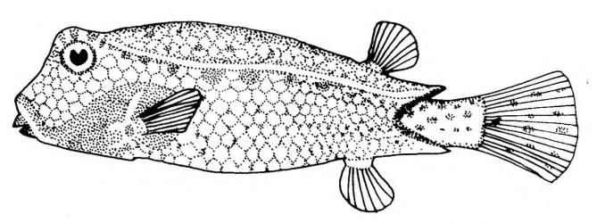

**Figure 2.33:** *Ostracion nasus*, shortnosed boxfish

| **POc** |  | *bʷaReu | ‘*Ostracion*, boxfish’ |
| --- | --- | --- | --- |
| PT | Misima | *bʷale(loga)* | ‘*Choerodon anchorago*, anchor trunkfish’ |
| SES | Lau | *kʷaleu* | ‘k.o. fish’ |
| **PROc** |  | *bʷar(o)-bʷar(o) | ‘*Ostracion*, boxfish’ (Lynch: PSO *bʷar(o)-bʷar(o)) |
| NCV | Mwotlap | *na-pʷay-pʷay* | ‘*Ostracion meleagris*, white-spotted boxfish’ |
| NCV | Uripiv | *(da)pur-pur* | ‘*Ostracion*, boxfish’ |
| **PCP** |  | *gʷao-gʷao | ‘*Ostracion*’ (Geraghty 1994) |
| Fij | Rotuman | *kao-kao* | ‘k.o. fish. When young, called *mod*’ |
| Fij | Wayan | *gʷā-gʷā* | ‘generic for boxfish’ |

The next two reconstructions, *toqa and *moa, are problematic. Lynch (pers. comm.) has suggested Proto Central Vanuatu *mʷatoqu ‘boxfish, *Ostracion*’ (Paamese *(u)matou*, Namakir *mʷa-mʷatoq*, Nguna *mʷatou*) which has echoes of both. There is also the possibility of parallel development, an outstanding characteristic of this fish being its resemblance in taste and texture to chicken, PCP *moa or *toa (Geraghty 1994: p. 166).

| **POc** |  | *toqa | ‘k.o. fish with toxic flesh, probably *Ostracion*’ |
| --- | --- | --- | --- |
| PT | Iduna | *(sisi)toʔa* | ‘pufferfish’ |
| **PFij** |  | *toa | ‘*Ostracion*’ (Geraghty 1994) |
| Fij | Bauan | *toa* | ‘a round fish like the *sumu-sumu*, trunkfish or Ostraciidae’ |

| **POc** |  | *moa | ‘boxfish’ |
| --- | --- | --- | --- |
| MM | Marovo | *moa (idere)* | ‘*Ostracion* spp., boxfish’ |
| **PNCV** |  | *mʷa(toqu) | ‘boxfish’ (Lynch pers. comm.) |
| NCV | Paamese | *(u)ma(tou)* | ‘boxfish’ |
| NCV | Namakir | *mʷa-mʷa(toq)* | ‘boxfish’ |
| NCV | Nguna | *mʷa(tou)* | ‘boxfish’ |
| **PCP** |  | *moa(moa) | ‘*Ostracion*’ (Geraghty 1994) |
| Fij | Rotuman | *moa* | ‘young kao-kao’ (see above) |
| **PPn** |  | *moa-moa | ‘Ostraciidae, boxfish’ (Hooper 1994) |
| Pn | Tongan | *mō-moa* | ‘cowfish’ |
| Pn | Pukapukan | *moa-moa* | ‘*Ostracion* or *Lactoria* (cowfish) spp.’ |
| Pn | Tokelauan | *moa-moa* | ’*Ostracion* or _Lactoria__ spp.’ |
| Pn | Rennellese | *moa-moa* | ‘generic for boxfish, coffinfish, trunkfish, cowfish’ |
| Pn | Samoan | *moa-moa* | ‘trunkfish, genera *Ostracion*’ |
| Pn | Hawaiian | *moa* | ‘k.o. trunkfish, *pahu*’ |

## 63. Puffers, toadfishes and blowfishes (Tetraodontidae); porcupinefishes and balloonfishes (Diodontidae)

Puffers are sluggish fish which fill the belly with air when disturbed, and then float to the surface. They are feeble swimmers. Closely related are porcupine fish which are also selfinflating, but distinguished by having moveable spines on head and body. Both are bottom dwellers, and the flesh of both is toxic (Munro 1967: pp.545, 548). Although ACD glosses PMP *taRutum as ‘porcupinefish, puffer fish, *Diodon* sp.’, the WMP and CMP reflexes listed refer only to porcupinefish, and the reference to pufferfish is no doubt to the spiny puffer, an alternative name for porcupinefish. In Ambon (CEMP) a reflex is the term for a durian and in Ponape (Mic) a term for both the fish and a soursop (also a fruit with prickles), while in languages of Borneo (Kelabit, Katingan) and the Lesser Sundas (Manggarai, Lamaholot) reflexes mean ‘porcupine’. Both emphasise the semantic connection with porcupinefish rather than the smooth pufferfish. Blust (2002:130) considers that because porcupines (the mammals) are not found in the Philippines where PMP was presumably spoken, the term’s original reference was to ‘porcupinefish’.

| **PMP** |  | *taRutu[m,ŋ] | ‘porcupinefish, *Diodon* sp.’ (ACD includes puffers) |
| --- | --- | --- | --- |
| **POc** |  | *taRutu(m,ŋ) | ‘*Diodon* spp., porcupinefish’ |
| MM | Nakanai | *talitu* | ‘pufferfish, blowfish’ |
| MM | Lihir | *tarut* | ‘*Diodon* spp., porcupinefishes (generic)’ |
| MM | Patpatar | *tarut* | ‘French porcupinefish’ |
| SES | Lau | *au* | ‘porcupinefish’ (shows loss of *R* before high vowels) |
| NCV | Mota | *terit* | ‘*Diodon* spp.’ |
| NCV | Dorig | *trit* | ‘*Diodon holocanthus*, *Diodon liturosus*’ |
| NCV | Uripiv | *daut* | ‘porcupinefish’ |
| NCal | Nêlêmwa | *dot* | ‘porcupinefish’ |
| NCal | Iaai | *kāt* | ‘porcupinefish’ |
| **PMic** |  | *tautu | ‘porcupine fish’ (Bender et al. 2003) |
| Mic | Kiribati | *tauti* | ‘puffer fish, *Diodon*’ |
| Mic | Puluwatese | *hə̄wɨ* | ‘large growth stage of edible long-spined puffer fish’ |
| Mic | Carolinian | *sōw* | ‘species of lagoon fish, poss. goatfish?’ |
| Mic | Ponapean | *sey* | ‘porcupine fish; soursop, *Annona muricata*’ |
| Mic | Mokilese | *joy* | ‘porcupine fish’ |
| **PCP** |  | *tautu | ‘*Diodon* sp.’ (Geraghty 1990) |
| Fij | Rotuman | *faufu* | ‘fish which inflates itself when caught: covered with spikes like a porcupine’ |
| **PPn** |  | *tautu | ‘*Diodon* spp., porcupine fish’ (Hooper 1994) |
| Pn | Niuatoputapu | *toutu* | ‘adult growth stage of porcupinefish’ |
| Pn | East Uvean | *tautu* | ‘Diodontidae (no distinction of genera or species)’ |
| Pn | Rennellese | *tautu* | ‘general name for balloon fish (porcupine fish)’ |
| Pn | Samoan | *tautu* | ‘fish, *Diodon* sp., with very sharp spines’ |
| Pn | Tokelauan | *tautu* | ‘*Diodon* sp.’ |
| Pn | Tikopia | *tautu* | ‘*Diodon* sp.’ |

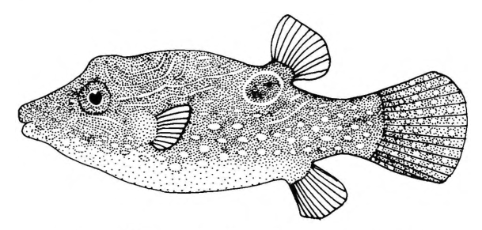

**Figure 2.34:** *Arothron leopardus*, leopard pufferfish

| **POc** |  | *[poto]poto | ‘pufferfish, porcupinefish’ |
| --- | --- | --- | --- |
| Adm | Titan | *(buli)poto-poto* | ‘porcupinefish’ |
| MM | Marovo | *poto* | ‘generic for all boxfish and pufferfish’ (*poto mariu* ‘porcupinefish, *Diodon* spp.’) |
| MM | Maringe | *pʰo-poto* | ‘k.o. pufferfish or blowfish, such as *Arothron*’ |
| NCV | Mwotlap | *wʊt-wʊt* | ‘*Arothron hispidus*, porcupinefish’ (white-spotted puffer)[^35] |
| NCV | Dorig | *vʊt-vʊt* | ‘*Arothron nigropunctatus*’ (black-spotted puffer) |
| NCV | Ambae | *(totoro) woto* | ‘porcupinefish’ |
| Fij | Wayan | *voto* | ‘spike or spines of a fish; prickle, thorn’ |
| **PPn** |  | *foto | ‘barb of stingray’ (pollex; see §66.6) |

| **POc** |  | *bʷoe-bʷoe | ‘pufferfish’ |
| --- | --- | --- | --- |
| MM | Tabar | *pu-pui* | ‘pufferfish’ |
| SES | Gela | *boe-bote* | ‘generic pufferfish, Tetradontidae’ (*-t-* unexpected) |
| SES | Longgu | *boe (sina)* | ‘*Diodon hystrix*, porcupinefish’ (*sina* ‘his/her younger sibling’) |
| SES | To’aba’ita | *boe (ni asi)* | ‘*Arothron hispidus*, pufferfish’ (lit. ‘inflated thing? of the sea’) |
| SES | Langalanga | *boe* | ‘*Arothron hispidus*’ (white-spotted puffer) |
| SES | Lau | *boe* | ‘toadfish’ |
| SES | ’Are’are | *poe* | ‘puffer fish’ (*poe haʔu* ‘porcupine fish’) |
| SES | Sa’a | *poe* | ‘porcupine fish’ |
| SES | Arosi | *boe* | ‘k.o. fish, very poisonous’ |
| **PNCV** |  | *bue-bue | ‘pufferfish’ (Clark 2009: 87) |
| NCV | Lewo | *pue-pue* | ‘k.o. fish, sometimes poison, can puff itself up’ |
| NCV | Namakir | *bue-bu* | ‘spineless puffer’ |
| NCV | South Efate | *pʷu(nopun)* | ‘Tetradontidae, pufferfish’ |
| SV | Anejom̃ | *(nu)pupou* | ‘pufferfish’ |
| NCal | Fwâi | *fū(rehâ)* | ‘*Arothron meleagris*’ (guineafowl puffer) |
| NCal | Nemi | *pʰū(reŋa)* | ‘*Arothron meleagris*’ |

cf. also:

| Fij | Wayan | *bū(tē)* | ‘generic for some Tetraodontidae, small to moderate-sized puffers’ |
| --- | --- | --- | --- |

| **POc** |  | *buli | ‘pufferfish’ |
| --- | --- | --- | --- |
| Adm | Titan | *buli* | ‘puffer, leatherjacket’ |
| Adm | Loniu | *pʷili* | ‘toadfish or puffer’ |
| Mic | Kiribati | *buni* | ‘Tetraodontidae’ |

cf. also:

| NNG | Manam | *bulai* | ‘pufferfish’ |
| --- | --- | --- | --- |
| NNG | Takia | *bului* | ‘pufferfish’ |
| NNG | Bing | *bulu(luy)* | ‘toadfish’ |

There is a term from Roro (PT) with form apparently cognate with PCP *jexejexe ‘*Arothron*’, but its gloss rules out an upgrading to a POc reconstruction.

| **PCP** |  | *jexejexe | ‘*Arothron*’ (Geraghty 1994) |
| --- | --- | --- | --- |
| Fij | Wayan | *seke-seke* | ‘*Canthigaster margaritata*, ocellated puffer’ |
| **PPn** |  | *teqe-teqe | ‘*Arothron* and *Canthigaster* spp., pufferfish’ (Hooper 1994) |
| Pn | Tongan | *teʔe-teʔe* | ‘k.o. fish that inflates itself when caught’ |
| Pn | Rennellese | *teʔe-teʔe* | ‘toadfish, balloonfish, puffers’ |
| Pn | Samoan | *tētē* | ‘immature globe fish’ |
| Pn | Kapingamarangi | *tētē* | ‘*Arothron stellatus*, starry toadfish’ |
| Pn | Tokelauan | *tētē* | ‘*Arothron meleagris*, guineafowl puffer’ |
| Pn | Hawaiian | *kēkē* | ‘*Arothron hispidus*’ (white-spotted puffer) |

cf. also:

| PT | Roro | *teʔe* | ‘jellyfish’ |
| --- | --- | --- | --- |
| Mic | Chuukese | *sekun* | ‘*Canthigaster* spp., smooth puffers’ |

| **PROc** |  | *bʷakaRe | ‘porcupine fish’ (Clark 2009:93, PNCV) |
| --- | --- | --- | --- |
| NCV | Mota | *pʷaɣare* | ‘urchin fish’ |
| NCV | Vera’a | *pʷaɣar* | ‘*Diodon* spp.’ |
| NCV | Mwotlap | *(na-)pʷɣay* | ‘*Diodon holocanthus*, porcupine fish’ |
| NCV | Namakir | *bʷaka* | ‘spiny puffer’ |
| NCV | Nguna | *pʷakae* | ‘*Diodon hystrix*, spiny puffer’ (spot-fin porcupinefish) |
| SV | Kwamera | *pʷei* | ‘spiny puffer’ |
| SV | Anejom̃ | *no-pʷɣai* | ‘*Diodon hystrix*, porcupinefish’ |
| Mic | Satawalese | *pɔkœre(ŋ)* | ‘*Pleuranacanthus sceleratus*, puffer’ |

cf. also:

| MM | Halia | *burukari* | ‘southern puffer’ |
| --- | --- | --- | --- |

## 64. Flying gurnards (Dactylopteridae)

Flying gurnards are semipelagic, with lesser powers of flight than the true flying fish. They are heavily armoured, with enormous wing-like pectorals. Essentially bottom dwellers, they are capable of short clumsy glide-like flights (Munro 1967: p. 541). Geraghty (1994: p. 149) proposes PFij *lulu, but no higher-level reconstruction has been made.

## 65. Remoras (Echeneididae)

Remoras (*Echeneis naucrates* and *Remora remora*), also known as suckerfish, have a modified adhesive disk on the upper surface of the head with which they attach themselves to large floating objects, frequently sharks. The Gela (SES) term for remoras is *rao-rago bagea*, literally ‘joined to sharks’. I have no POc reconstruction for remora. I noted in §4 that the Motu reflex of POc *maŋewa ‘k.o. shark’ and the PCP reflex of *bakewa ‘shark (generic)’ denote the remora, not the shark. Hooper (1994: p.216) proposes PPn *tali-tali-quli ‘Echeneis sp., remora, and *Naucrates ductor*, pilot fish’ with suggested etymology *tali-tali ‘wait upon’ and *quli ‘to steer’.

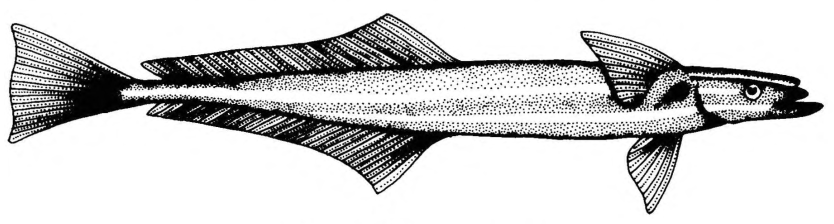

**Figure 2.35:** *Remora remora*

## 66. Fish parts

### 66.1. Roe

| **PAn** |  | *biRaS | ‘roe, fish eggs’ (dbl. *piRa) (ACD) |
| --- | --- | --- | --- |
| **POc** |  | *biRa | ‘roe, fish eggs’ (ACD: *piRa) |
| NNG | Lukep | *bira* | ‘crayfish eggs’ |
| PT | Dobu | *bila* | ‘fish roe’ |
| PT | Tawala | *bile* | ‘roe’ |
| PT | Tubetube | *bile(na)* | ‘fish internals’ |
| PT | Gapapaiwa | *bire* | ‘roe’ |
| PT | Hula | *pila* | ‘roe’ |
| MM | Tolai | *bira* | ‘fat’ |
| MM | Marovo | *bira* | ‘fish eggs’ |
| MM | Roviana | *bira(na)* | ‘the hard roe of fish’ |
| SES | Gela | *bila* | ‘organ of a fish’ |
| SES | Longgu | *bila(na)* | ‘fish eggs’ |
| SES | Lau | *bila* | ‘roe of fish, yolk of egg’ |
| SES | Kwaio | *bila(na)* | ‘roe’ |
| SES | Sa’a | *pile(na)* | ‘roe of fish, yolk of egg; to spawn’ |
| SES | ’Are’are | *pira(na)* | ‘roe of fish’ |
| SES | Arosi | *bira(na)* | ‘roe of a fish, yolk of an egg’ |
| Mic | Kiribati | *bia* | ‘growth, tumor, gland, knob, excresence, fish ovaries’ (*pia* ‘fish roe’) |
| Mic | Marshallese | *pia* | ‘fish roe’ |

cf. also:

| NNG | Mangap | *barā(na)* | ‘fish roe’ |
| --- | --- | --- | --- |
| Fij | Wayan | *via* | ‘fish eggs, roe’ |

In Bauan Fijian and some Polynesian languages fish roe are called by the literal compound ‘fish eggs’ (Bauanyaloka *ni ika*. Tongan *fua ʔi ika* etc.).

### 66.2. Gills

| **PMP** |  | *hasaŋ | ‘gills’ (Zorc 1994) |
| --- | --- | --- | --- |
| **POc** |  | *qasaŋ | ‘gills’ |
| Adm | Mussau | *asaŋe* | ‘internal gills’ |
| Adm | Andra | *aseŋa* | ‘gills’ |
| NNG | Gitua | *asana* | ‘gills’ |
| NNG | Lukep | *kaŋana* | ‘gills’ |
| NNG | Yabem | *(ŋ)asaŋ* | ‘gills’ |
| NNG | Ali | *(s)aseŋ* | ‘gills’ |
| NNG | Kaiep | *(l)asaŋ* | ‘gills’ |
| PT | Motu | *lada* | ‘gills’ |
| MM | Nalik | *isaŋ* | ‘gills’ |
| MM | Tabar | *aca* | ‘gills’ |
| MM | Madak | *(m)aseŋ* | ‘gills’ |
| MM | Halia | *(w)esaŋa* | ‘gills’ |
| MM | Taiof | *n-esaŋ* | ‘gills’ |
| MM | Babatana | *(j)ajaŋa* | ‘gills’ |
| MM | Marovo | *asaŋa* | ‘gills’ |
| MM | Roviana | *asaŋa* | ‘gills’ |
| SES | Gela | *(s)asaŋa* | (retention of final consonant + echo vowel indicates probable borrowing from a NW Solomonic language) |
| SES | Lengo | *seŋe* | ‘gills’ |

cf. also:

| Adm | Lou | *lisa-n* | ‘red inner gills of a fish’ |
| --- | --- | --- | --- |
| SES | Sa’a | *laŋasi* | ‘gills’ |
| SES | Arosi | *raŋasi* | ‘gills’ |

| **POc** |  | *koro | ‘gills’ |
| --- | --- | --- | --- |
| MM | Vitu | *koro-koro* | ‘gills’ |
| MM | Bulu | *kolo-kolo* | ‘gills’ |
| Mic | Kiribati | *ō* | ‘gills’ |
| Mic | Marshallese | *oṛ* | ‘gills’ |
| Mic | Chuukese | *wōr* | ‘gills’ |
| Mic | Woleaian | *woẓo* | ‘gills’ |

| **POc** |  | *gara | ‘gills’ |
| --- | --- | --- | --- |
| NNG | Mindiri | *gar-gara(ŋ)* | ‘gills’ |
| NNG | Megiar | *(gi)gare(n)* | ‘gills’ |
| NNG | Takia | *(gi)gare(n)* | ‘gills’ |
| PT | Lala | *ala-ala* | ‘gills’ |
| NCV | Ambae | *gala(vana)* | ‘gills’ |
| NCal | Nyelâyu | *yāra(r)* | ‘gills’ |

cf. also:

| PT | Kilivila | *gare(na)* | ‘gills’ |
| --- | --- | --- | --- |

PPn *lau-lau-mea ‘fish gills’ (*‘external part, surface’ *mea* ‘red, reddish’) has also been reconstructed (pollex).

### 66.3. Scales

A POc verb, *qunapi- ‘scale a fish’ can be reconstructed, and it appears that a noun *qunapi ‘fishscales’ was derived by back-formation in POc, existing as a doublet alongside *qunap. Polynesian reflexes of the following reconstruction refer to turtle shell as well as fish scale.

| **PAn** |  | *quSaNap | ‘scale of fish’ (ACD) |
| --- | --- | --- | --- |
| **POc** |  | *qunap[i] | ‘fishscale’ (Dempwolff 1938) |
| Adm | Mussau | *unei* | ‘fishscale’ |
| Adm | Seimat | *uli* | ‘fishscale’ |
| NNG | Tuam | *anavu* | ‘fishscale’ |
| NNG | Malai | *anuvu* | ‘fishscale’ |
| NNG | Gitua | *anap* | ‘fishscale’ |
| NNG | Mindiri | *kunapi(n)* | ‘fishscale’ |
| NNG | Wogeo | *una* | ‘fishscale’ |
| PT | Duau | *kunaha* | ‘fishscale’ |
| PT | Diodio | *kʷanava* | ‘fishscale’ |
| PT | Iduna | *kʷanava* | ‘fishscale’ |
| PT | Tawala | *(we)nawa* | ‘fishscale’ |
| PT | Misima | *(un)una* | ‘fishscale’ |
| PT | Maopa | *unavi* | ‘fishscale’ |
| PT | Hula | *ɣuna* | (*ɣunavea* (vt) ‘scale fish’) |
| PT | Motu | *una* | (*unahi* (vt) ‘seal e fi sh’) |
| PT | Roro | *una* | ‘fishscale’ |
| MM | Lavongai | *kunep* | (All the MM terms reflect *k-) |
| MM | Tigak | *kunap* | ‘fishscale’ |
| MM | West Kara | *kunaf* | ‘fishscale’ |
| MM | Tiang | *kuna* | ‘fishscale’ |
| MM | Bola | *ɣona* | ‘fishscale’ |
| SES | Lau | *unafa(na)* | ‘fishscale’ |
| SES | Kwaio | *una-una* | (*unafia* ‘scale fi sh’) |
| SES | Sa’a | *uneha(ʔa)* | ‘fish or snake scales’ |
| SES | Arosi | *una* | (*unahi* ‘scale fi sh’) |
| SV | Sye | *niŋevi-* | ‘fishscale’ |
| SV | Anejom̃ | *ninehe-* | ‘fishscale’ |
| Fij | Rotuman | *una* | ‘fishscale’ |
| Fij | Wayan | *una* | ‘fishscale’ |
| **PPn** |  | *quna | ‘fish scale, turtle shell’ (pollex) |
| Pn | Niuean | *una* | ‘turtle shell’ |
| Pn | Tongan | *ʔuno-ʔuno* | ‘fish scales, turtle shell’ |
| Pn | Samoan | *una* | (*una laumei* ’scale of hawk__s bill turtle, i.e. tortoise-shell’) |
| Pn | Pukapukan | *unawi* | ‘fish scales’ (*una* ‘scale of turtle shell’) |
| Pn | Tikopia | *unafi* | ‘fish scales’ (*una* ‘carapace of marine turtle’) |
| Pn | Hawaiian | *unahi* | ‘fish scales’ (*una* ‘shell of turtle or tortoise’) |

cf. also:

| PT | Sinaugoro | *cunave* | ‘fish scales’ |
| --- | --- | --- | --- |
| Pn | Niuean | *hinafi* | ‘fish scales, to scale a fish’ |

### 66.4. Fins

Many languages distinguish between pectoral (breast), dorsal (back), caudal (tail) and ventral (abdominal) fins. Reconstructions have been made for the first two. The reconstruction of the next etymon, POc *banic ‘arm, hand, wing, fin (probably pectoral)’, entails some minor formal problems. All cognates reflect initial *b- except those in the Central Papuan languages Balawaia, Motu and Mekeo, which reflect *p-. Blust (ACD) reconstructs PMP *pani(d,j) with either *-d or *-j as final consonant. The only Oceanic reflex with an etymological final consonant is Vitu *baniti-*, pointing to POc *-t or *-c. The most straightforward analysis is that PMP *panij became POc *banic by regular sound change. The final consonants of Wampur *bani-t* and Mapos Buang *bani-s* can be ignored, as they reflect a probable construct suffix found on inalienably possessed nouns in Huon Gulf languages. The POc meaning of this term had clearly been extended beyond ‘wing’ to include the pectoral fins of fish, the wings of birds and the arms of human beings.

| **PMP** |  | *panij | ‘wing’ (ACD; Dempwolff 1938) |
| --- | --- | --- | --- |
| **POc** |  | *banic | ‘arm, hand, wing, fin (probably pectoral)’ |
| Adm | Seimat | *paun* | ‘pectoral fin’ |
| Adm | Wuvulu | *pani-* | ‘hand’ |
| Adm | Aua | *pani-* | ‘hand, fin’ |
| Adm | Kaniet | *pani* | ‘wing, hand, fin’ |
| Adm | Nyindrou | *bani-n* | ‘wing’ |
| Adm | Pak | *beni-n* | ‘fin’ |
| Adm | Nauna | *pin* | ‘wing’ |
| Adm | Mondropolon | *pani-n* | ‘wing’ |
| Adm | Drehet | *peni-ŋ* | ‘wing’ |
| NNG | Gedaged | *bani-n* | ‘fin, wing’ |
| NNG | Takia | *bani-* | ‘forelegs, hand, arm’ |
| NNG | Kairiru | *panin* | ‘fin’ |
| NNG | Tumleo | *pain* | ‘fin’ |
| NNG | Wampur | *bani-t* | ‘wing’ |
| NNG | Mapos Buang | *bani-s* | ‘fin, wing’ |
| PT | Gumawana | *pane-pane(na)* | ‘fish fins, bird’s wing’ |
| PT | Balawaia | *vane* | ‘wing, fin’ (for †*bani*) |
| PT | Motu | *hani* | ‘fin, wing’ (for †*bani*) |
| PT | Mekeo | *pa-pani* | ‘wing-like object, incl. fins’ (for †*bani*) |
| MM | Vitu | *baniti-* | ‘wing, upper arm’ |
| NCV | Mota | *panei, paniu* | ‘hand and arm, wing, pectoral fin, pig’s shoulder’ |
| NCV | Merlav | *bani* | ‘wing’ |
| NCV | Atchin | *na-mben* | ‘wing, sail, armlet’ |
| NCal | Iaai | *beñi-n* | ‘hand, arm, fin’ |
| NCal | Iaai | *la-beñi-n* | ‘wing’ |
| Mic | Marshallese | *pā* | ‘arm, hand, wing, fin’ |
| Mic | Carolinian | *ppʷan* | ‘pectoral fin and attached bone of fish’ |
| Mic | Ulithian | *pal* | ‘ventral fin; hand’ |

POc *kaba (N) ‘wing’, (v) ‘flap wings’ (this volume, p.275) may be reduplicated to refer to the action of flapping back and forth, and in Polynesian languages this meaning is extended to include the action of fins, flippers and wings together with the name of the bodypart. Similarly, a number of Papuan Tip languages, Gumawana *pane-panena*, Molima *pape*, Wedau *papena* and Mekeo *pa-pani* use terms unrelated to *kaba-kaba to refer to both a bird’s wing or its flapping action and for a fish fin/turtle flipper.

| **PEOc** |  | *kaba-kaba | ‘to flap the wings’ |
| --- | --- | --- | --- |
| SES | Lau | *ʔaba-ʔaba* | ‘to flap the wings’ |
| **PPn** |  | *kapa-kapa | (1) ‘lateral fins’; (2) ‘flap wings’ (pollex) |
| Pn | Tongan | *kapa-kapa* | ‘flap the wings, side fin’ |
| Pn | Rennellese | *kapa-kapa* | ‘flippers, as of turtle, stingray, whale; base of fish fins’ |
| Pn | Samoan | *ʔapa-ʔapa* | ‘fin’ (*ʔapa* ’to beat, of bird__s wing, turtle flipper etc.’) |
| Pn | Pukapukan | *kapa-kapa* | ‘fin of fish, wing of bird, claw of turtle, arm of baby’ |
| Pn | Tikopia | *kapa-kapa* | ‘pectoral fins; to flap, of wings’ |
| Pn | Tokelauan | *kapa-kapa* | ‘of sharks, stingray, turtle etc., lateral fin, flippers’ |

cf. also:

| MM | Tinputz | *kevā* | ‘fish fins’ |
| --- | --- | --- | --- |
| Pn | Tongan | *kapo(ŋa)* | ‘back fin’ |

The following is a variant of the same word.

| **PMP** |  | *kapi-kapi | ‘fin’[^36] |
| --- | --- | --- | --- |
| **POc** |  | *kapi-kapi | ‘pectoral fins’ |
| NNG | Labu | *hi* | ‘fish fin’ |
| MM | Marovo | *kapi-kapi* | ‘pectoral fins’ |

Alternatively, a reflex of POc *taliŋa ‘ear’ is sometimes used to refer to a pectoral fin.

| **POc** |  | *taliŋa | ‘pectoral fins’ (semantic extension of *taliŋa ‘ear’) |
| --- | --- | --- | --- |
| Adm | Mussau | *(ū-)taliŋa* | ‘external gills’ (lit. ‘feather + ear’) |
| PT | Motu | *taia* | ‘gill fins of fish’ |
| SES | Kwaio | *aliŋa(na-iʔa)* | ‘fish fin’ (lit.‘ear of fish’) |
| NCV | Mwotlap | *delŋe* | ‘pectoral fins’ |
| Fij | Rotuman | *faliŋa* | ‘pectoral fins’ |

| **PMP** |  | *siRik | ‘dorsal fin’[^37] |
| --- | --- | --- | --- |
| **POc** |  | *siRiko | ‘fish fin’ |
| MM | Nakanai | *siliko-liko* | ‘fins’ |
| NCV | Uripiv | *siki* | ‘fin’ |
| Fij | Wayan | *siko-silo* | ‘fin’ |

cf. also:

| Mic | Ponapean | *sike* | ‘top and bottom fins of a fish’ (*s* for †*t*) |
| --- | --- | --- | --- |

| **PMic** |  | *iŋi | ‘dorsal fin’ (Bender et al. 2003) |
| --- | --- | --- | --- |
| Mic | Sonsorolese | *iŋi* | ‘generic fin’ |
| Mic | Sonsorolese | *iŋi ri varo* | ‘ventral fin’ |
| Mic | Sonsorolese | *iŋi ri waor* | ‘dorsal fin’ |
| Mic | Woleaian | *īŋi* | ‘fin of fish’ |
| Mic | Mortlockese | *yīŋ* | ‘dorsal fin’ |
| Mic | Carolinian | *iŋi(l)* | ‘dorsal fin’ |
| Mic | Puluwatese | *yīŋ* | ‘dorsal fin’ |

| **PWOc** |  | *sio(R,r)a | ‘fish fin’ |
| --- | --- | --- | --- |
| PT | Kilivila | *siola* | ‘fin’ |
| MM | Babatana | *si-sioro* | ‘fins of fish’ |

### 66.5. Fish gullet

The next POc reconstruction has general reference to ‘middle’, its meaning narrowing to fish gullet only at PPn level.

| **PMP** |  | *kempuŋ | ‘abdomen, belly’ (Dempwolff 1938) |
| --- | --- | --- | --- |
| **POc** |  | *kobu(ŋ) | ‘middle, waist, belly’ |
| SES | Gela | *obu* | (i) ‘the middle’; (ii) ‘waist of a man’ |
| SES | Sa’a | *upu-upu* | ‘middle, waist, a swelling’ |
| SES | Arosi | *ubu(na)* | ‘middle’ |
| **PPn** |  | *kōpū | ‘fish gullet’ |
| Pn | Tongan | *kōpū* | ‘fish gullet’ |
| Pn | East Futunan | *kōpū* | ‘fish gut’ |
| Pn | Tokelauan | *kōpū* | (i) ‘throat’; (ii) ‘(fish) gut, stomach’ |
| Pn | Māori | *kōpū* | ‘belly, womb’ |
| Pn | Hawaiian | *ōpū* | ‘gizzard, maw of animal, crop of bird’ |

### 66.6. Barb of stingray

Reflexes of POc *poto(k) ‘thorn’ (vol.3,125) have come to refer to the spike or spines of a fish in Wayan Fijian and the barb of a stingray in Polynesian languages.

| **PCP** |  | *voto | ‘thorn, prickle; spike or spines of a fish’ |
| --- | --- | --- | --- |
| Fij | Rotuman | *hofu* | ‘sting or piercer of stingray’ |
| Fij | Wayan | *voto* | ‘spike or spines of a fish’ |
| **PPn** |  | *foto | ‘barb of stingray’ |
| Pn | Tongan | *foto* | ‘barb of stingray’ |
| Pn | Niuean | *foto* | ‘thorn, barb, spike, bristle’ |
| Pn | East Futunan | *foto* | ‘barb of stingray’ |
| Pn | Rennellese | *hoto* | ‘barb, as on a stingray’s tail’ |
| Pn | Samoan | *foto* | ‘barb of stingray’ |
| Pn | Māori | *hoto* | ‘barb of stingray’ |

## Notes

[^1]: I am particularly grateful to Malcolm Ross who has spent many hours checking and suggesting solutions to problematic cognate sets, and to Paul Geraghty for a host of detailed comments. Andrew Pawley has also commented on earlier drafts and made many useful suggestions. Others who have contributed over the years that this work has been in progress include Simon Foale, Alexandre François, John Lynch. Alice Pomponio, the late Phil Quick, Kevin Salisbury, Ian Scales and David Walsh.
[^2]: Apart from general dictionaries and wordlists, the following lists of fish names were consulted: Andra, McEldowney (1995); Chuukese. Davis (1999); Dobu, Lithgow (1975); Gela, Foale (1998); Kadavu Fijian, Kikusawa (1995); Kapingamarangi. Lieber (1994); Kiribatese, Thaman & Tebano (n.d.); Lau (of Malaita), Akimichi (1978); Lau Fijian, Paul Geraghty (pers. comm.); Motu, Oram (n.d.); Marovo, Hviding (1990, 1996, 2005); Marquesan, Lavondes (1977); Mbunai Titan, Akimichi & Sakiyama (1991); Misima, Kinch (1999b); Mutu. Pomponio (n.d.); Nadroga Fijian, Paul Geraghty (pers. comm.); Nduke, Ian Scales (pers. comm.); Niuatoputapu. Dye 1983; Ponam. Carrier (1982); Pukapuka, Kevin Salisbury (pers. comm.); Raga, David Walsh (pers. comm.); Satawalese. Akimichi & Sauchomal (1982); Teop, Shoffner (1976); Uvean (Wallisian), Rensch (1983).
[^3]: Other totals recorded are 67 for Gela (SES), 66 for Wayan Fijian, 64 for Titan (Adm) and 62 for Satawalese (Mic).
[^4]: Geraghty (1994) has *gio.
[^5]: Geraghty comments that the vowel sequence *-uo* is rare in Central Pacific languages, and suggests that PPn *-io may be regularly derived (pers. comm.).
[^6]: An association with POc *pulan ‘moon’ is suggested, possibly a reference to its silvery colour.
[^7]: Clark also suggests POc *niale(u,wa) ‘freshwater eel’ (see previous set).
[^8]: Biggs’ request appeared in the an-lang list on 7 May 1999.
[^9]: The word *ato* is not glossed by Chowning, but means ‘message, messenger’ in closely related Bariai.
[^10]: The great barracuda or giant sea pike, *Sphyraena barracuda*, is sometimes referred to as *Sphyraena picuda* or *Agrioposphyraena barracuda*.
[^11]: The term *malisa* ‘barracuda’ is quite widespread in Papua New Guinea, spread through Tok Pisin. which adopted it from Patpatar.
[^12]: Barnett (1978: 57) names ten kinds of *ʔurahu* in Arosi, named for patterning or habitat or behaviour.
[^13]: Oceanic cognates justify a gloss of ‘rock cod’ only for PCP. However, Balinese *baŋ-baŋ* ‘k.o. large sea fish’ may be external evidence for the gloss at POc level.
[^14]: Ross (1994a: 418) discounted the Motu term as cognate on the basis that the initial consonants of Motu *dono* ‘brown spotted rock cod’, Lala *dono* ‘k.o. fish’ and Roro *tono* ‘k.o. fish’ all reflect POc *s-. However Motu *d-*, unlike the other two. also reflects POc *d.
[^15]: Iaai normally does not retain final consonants, so this may have been a compound (John Lynch, pers. comm.).
[^16]: Blust (1986: 73) lists a number of fish names with prefix *mala* from Cebuano (WMP) (*mala-patí* ‘k.o. fish’. *mala-sugí* ‘swordfish, sailfish’, *mala-tindúk* ‘mackerel scad’), and one from Samar (WMP) (*mala-punti* ‘blue-spotted sea perch’), but there is insufficient information to identity a common meaning.
[^17]: Pendau (WMP) *utur* ‘jobfish’ (Phil Quick pers. conun.) and Sangir *utude* ‘kind of deep-sea fish caught by line’ (ACD).
[^18]: For a another example of *-wa becoming *-o* see POc *maŋewa (p.31).
[^19]: *Lethrinus miniatus* is the trumpet emperor, a different fish from *Lethrinus olivaceus*. the long-nosed emperor, albeit one with which it is often confused. *Lethrinus elongatus* is a synonym for *Lethrinus olivaceus*, ‘long-nosed emperor’ [*Lethrinus miniatus* or_Lethrinus olivaceus_!].
[^20]: NCV items are due to John Lynch (pers. comm.)
[^21]: Nehan *aŋ-uaŋ* is a reduplicated reflex. As POc *w is lost in NW Solomonic languages, I infer that *-uaŋ* reflects an earlier interstage *kuaŋo ‘emperor’.
[^22]: Bender et al. reconstruct PCMic *tawu ‘a fish’, but add ‘the WOL and KIR forms are incompatible and probably both do not belong in this set’.
[^23]: Geraghty (2010) argues that PPn *wete may be a regular reflex of PCP *teu involving the following changes: (i) lowering of the final vowel to *o. (ii) breaking of the vowel *o* as *we*, and (iii) metathesis to *wete. He has tracked the same series of changes in PCP *deu ‘unravel’ > PPn *wete ‘untie’.
[^24]: Admiralties terms apparently reflect Proto Admiralty *mʷacasei with some irregularities. Most other items reflect POc *mʷacasi.
[^25]: Disambiguated from POc *buna(r,R) by evidence from Palauan *bils* and Pendau *bunag* (R. Blust pers. comm.)
[^26]: PCP *tuvu reflects the same assimilation of *-a- to *-u- as PCP *tukuku (< POc *takuŋ) (§44).
[^27]: The formal similarity to PEOc *lapi is probably coincidental.
[^28]: Reconstructed on the basis of Pendau (WMP) *lapeʔ* ‘parrotfish’ (Phil Quick pers. comm.), together with the Oceanic evidence.
[^29]: *Hipposcarus harid* is an Indian Ocean species closely related to *Hipposcarus longiceps* (Kailola 1987-1991:377, FishBase)
[^30]: The species complex comprises *Chlorurus gibbus* in the Red Sea. *Chlorurus strongylocephalus* in the Indian Ocean and *Chlorurus microrhinos* in the west-central Pacific (FishBase).
[^31]: Based on Pendau (WMP) *aroŋo* ‘*Acanthurus leucosternon*, surgeonfish’ (Phil Quick pers. comm.) together with the Oceanic cognates.
[^32]: The Rotuman is in some doubt because of the irregular initial and the specific definition, though the final vowel is regular (Geraghty 1994:161).
[^33]: Reflected by Ambon *(al)ali* ‘halibut, flounder’ and the Oceanic data.
[^34]: Also listed are a number of terms supporting PNCV *(s,t)umu(s,t)(V) ‘rabbitfish. *Siganus* spp.’ (Vera’a *ʔumus*, Dorig *smut*, Lakon *tumuh*, all *Siganus doliatus*, the last two also *Siganus canaliculatus*, Mota *sumut* ‘k.o. fish’. Uripiv *sumus*, S Efate *smʷos*, both ‘rabbitfish’). If these are related to POc *jumu, the PNCV reconstruction is *sumut-i and a final POc consonant *-t is indicated (Alex François. John Lynch, pers. comm.).
[^35]: Alex François (pers. comm.) points out that these North Vanuatu languages (+ other reflexes) unambiguously point to a sequence of vowels *u-o, indicating PNCV *vutovuto.
[^36]: WMP Kagayanen *kapi-kapi* ‘fin’ (dorsal), Murut *ka-kapi* ‘ventral fin’, Javanese *kɛpɛt* ‘fin’ and Balinese *kepes* ‘fin (generic)’ (CAD) support reconstruction of PMP *kapi-kapi ‘fin’.
[^37]: WMP cognates: Palauan and Molbog *sirik*, Minangkabau and Bugis *siriʔ*, all ‘(dorsal) fin’ (Tryon 1995) support reconstruction of PMP *siRik ‘dorsal fin’.